###### Virtualisation et Cloud - TEK-UP University

# LAB10 : Kubernetes

### Objectifs

- Créer un Cluster Kubernetes avec des instances EC2
- Faire le déploiement d'un serveur web Nginx

[figure not shown]

## Préparations des VMs

**- Étape 1 : Création des instances EC2**

- On av utiliser trois (03) instances EC2 avec les caractéristiques suivantes :
  - AMI : Ubuntu 18.04.6 LTS
  - Instance type : t2.meduim (2vCPU, 4Go RAM)
  - Stockage : 8 Go
  - Groupe de sécurité :
    - Créez un nouveau groupe de sécurité "k8s-Security Group" avec une seule régle : permettre tous le trafic depuis n'importe ou.
    - Utilisez ce groupe pour les trois instances

[figure not shown]

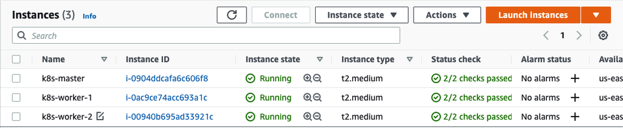

**- Étape 2 : Modification des hostnames**

- Connectez vous à chacune des trois instances et modifiez les hostnames.

> Tapez sur la première instance :

```python
$ sudo hostnamectl set-hostname "k8s-master"
```

```python
$ exit
```

> Tapez sur la deuxième instance :

```python
$ sudo hostnamectl set-hostname "k8s-worker-1"
```

```python
$ exit
```

> Tapez sur la troisième instance :

```python
sudo hostnamectl set-hostname "k8s-worker-2"
```

```python
$ exit
```

## Installation de Docker : Master & Workers

- Reconnectez vous à vos instances en mode root

```python
sudo su
```

**Étape 1 : Désactivation du Firewall**

```python
 ufw disable
```

**Étape 2 : Désactivation swap**

```python
swapoff -a
sed -i '/swap/d' /etc/fstab
```

```
- swapoff désactive la pagination sur les périphériques ou fichiers indiqués.
- Quand l'option -a est utilisée, la pagination est désactivée  sur  tous  les  périphériques  ou  fichiers d'échange connus
```

```
- La finalité de kubernetes est d'optimiser l'utilisation des ressources autant que possible
- Tous les déploiements doievent être épinglés avec des limites CPU/mémoire
- Ainsi le Scheduler doit sélectionner une machine pour un POD sans prendre en considération le swap
```

**Étape 3 : Mise à jour la configuration réseau sysctl de Kubernetes**

```python
cat <<EOF > /etc/sysctl.d/k8s.conf
net.bridge.bridge-nf-call-ip6tables = 1
net.bridge.bridge-nf-call-iptables = 1
EOF
```

## Installation de Docker : Master & Workers

**- Étape 1 : Installation Docker**

```python
curl -fsSL https://download.docker.com/linux/ubuntu/gpg | sudo apt-key add -
add-apt-repository \
   "deb [arch=amd64] https://download.docker.com/linux/ubuntu \
   $(lsb_release -cs) \
   stable"
```

```python
apt -y update
apt install -y docker-ce
```

**- Étape 2 : Configuration du pilote cgroup**

- Modifiez Docker pour utiliser le pilote cgroup systemd

```python
echo '{
  "exec-opts": ["native.cgroupdriver=systemd"]
}' > /etc/docker/daemon.json
```

```python
systemctl daemon-reload
```

```python
systemctl enable --now docker
```

## Installation de Kubernetes : Master & Workers

**- Étape1 : Ajout du référentiel de Kubernetes**

- Ajoutez le référentiel Kubernetes à votre gestionnaire de packages

```python
curl -s https://packages.cloud.google.com/apt/doc/apt-key.gpg | apt-key add -
cat <<EOF >/etc/apt/sources.list.d/kubernetes.list
deb http://apt.kubernetes.io/ kubernetes-xenial main
EOF
```

**- Étape 2 : Installation des composants nécessaires pour Kubernetes**

> Trois composants sont nécessaires :
> - kubeadm : le toolbox le plus populaire pour créer et initialiser un cluster Kubernetes
> - kubelet : le composant qui s'exécute sur toutes les machines de votre cluster et fait des actions comme le démarrage des pods et des conteneurs
> - kubectl : CLI utilisé pour communiquer avec le cluster

```python
apt -y update
apt install -y kubeadm kubectl kubelet
```

**- Étape 3 : Configuration kubelet**

```python
systemctl enable --now kubelet
```

## Initialisation du Master node (Control plane)

**- Étape 1 : Initialisation**

- Pour initialiser le Master node (control plane), on utilise la commande "kubeadm init"
- Tapez cette commande pour créer et initialiser le "control plane" de votre cluster

```python
kubeadm init
```

- Comme résultat, vous aurez :
> - un message qui confirme l'initialisation du control palne et comment le joindre
> - Une liste de commandes suggérées pour accéder au cluster

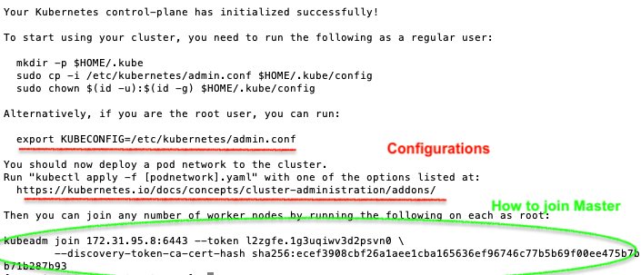

```python
Your Kubernetes control-plane has initialized successfully!

To start using your cluster, you need to run the following as a regular user:

  mkdir -p $HOME/.kube
  sudo cp -i /etc/kubernetes/admin.conf $HOME/.kube/config
  sudo chown $(id -u):$(id -g) $HOME/.kube/config

Alternatively, if you are the root user, you can run:

  export KUBECONFIG=/etc/kubernetes/admin.conf

You should now deploy a pod network to the cluster.
Run "kubectl apply -f [podnetwork].yaml" with one of the options listed at:
  https://kubernetes.io/docs/concepts/cluster-administration/addons/

Then you can join any number of worker nodes by running the following on each as root:

kubeadm join 172.31.95.8:6443 --token l2zgfe.1g3uqiwv3d2psvn0 --discovery-token-ca-cert-hash sha256:ecef3908cbf26a1aee1cba165636ef96746c77b5b69f00ee475b7bb71b287b93
```

- Copiez la commande join dans un fichier

**- Étape 2 : Configuration-utilisation de la commande kubectl**

> Pour accéder au cluster en tant que root, tapez la ligne de commande suivante :

```python
export KUBECONFIG=/etc/kubernetes/admin.conf
```

> Pour pouvoir utiliser les commandes kubectl en tant que utilisateur non root(regular user), tapez les lignes de commandes suivantes en tant que utilisateur non root:

```python
mkdir -p $HOME/.kube
```

```python
sudo cp -i /etc/kubernetes/admin.conf $HOME/.kube/config
```

```python
sudo chown $(id -u):$(id -g) $HOME/.kube/config
```

**- Étape 3 : Déploiement d'une interface réseau CNI (Container Network Interface)**

> - Un cluster Kubernetes a besoin d'un réseau interne spécifique pour permettre la communication entre les Pods et les Services du cluster.
> - On va utiliser l'une des solutions les plus utilisées : Calico

```python
kubectl apply -f https://docs.projectcalico.org/manifests/calico.yaml
```

**- Étape 3 : Vérification**

- Pour consulter la liste des noeuds dans le cluster, tapez la commande suivante :

```python
kubectl get nodes
```

- Pour superviser continuement la mise à jour des noeuds du cluster, tapez :

```python
watch kubectl get nodes
```

## Joindre le Master : Worker nodes

- Pour rejoindre le master node, exécutez la commande "kubeadm join" sur chaque Worker node (VM2 et VM3)
  - Il faut utiliser la commande relative à votre master : remplacez les paramètres d'accès par les votres

    ```
    Si vous n'avez pas copié la commande join dans un fichier, vous pouvez l'obtenir en tapant la ligne de commande suivante :
    kubeadm token create --print-join-command
    ```

```python
kubeadm join 172.31.95.8:6443 --token l2zgfe.1g3uqiwv3d2psvn0 --discovery-token-ca-cert-hash sha256:ecef3908cbf26a1aee1cba165636ef96746c77b5b69f00ee475b7bb71b287b93
```

- Après exécution de la commande "kubeadm join", vous aurez le message suivant :

```python
This node has joined the cluster:
* Certificate signing request was sent to apiserver and a response was received.
* The Kubelet was informed of the new secure connection details.

Run 'kubectl get nodes' on the control-plane to see this node join the cluster.
```

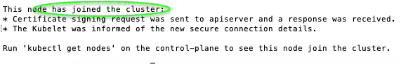

- Coté Master node, vérifier la présence des noeuds Worker 1 et 2

```python
kubectl get nodes
```

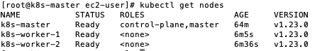

```python
NAME           STATUS   ROLES                  AGE     VERSION
k8s-master     Ready    control-plane,master   64m     v1.23.0
k8s-worker-1   Ready    <none>                 6m5s    v1.23.0
k8s-worker-2   Ready    <none>                 6m36s   v1.23.0
```

## Déploiement d'un serveur web Nginx

- Comme premier exemple, on va faire le déploiement de deux serveurs web Nginx.

**- Étape 1 : Nginx deployment**

- Consultez le descripteur Yaml du fichier de déploiement Nginx (accessible sur le lien : https://k8s.io/examples/application/deployment.yaml)

```python
apiVersion: apps/v1
kind: Deployment
metadata:
  name: nginx-deployment
spec:
  selector:
    matchLabels:
      app: nginx
  replicas: 2 # tells deployment to run 2 pods matching the template
  template:
    metadata:
      labels:
        app: nginx
    spec:
      containers:
      - name: nginx
        image: nginx:1.14.2
        ports:
        - containerPort: 80
```

- Pour faire le déploiement, tapez la ligne de commande suivante (Master node) :

```python
kubectl apply -f https://k8s.io/examples/application/deployment.yaml
```

- Vérifiez le lancement des PODs

```python
kubectl get pods
```

```python
# Résultat
NAME                               READY   STATUS    RESTARTS   AGE
nginx-deployment-9456bbbf9-crhr9   1/1     Running   0          18s
nginx-deployment-9456bbbf9-rpn8w   1/1     Running   0          18s
```

```python
kubectl get deploy
```

```python
# Résultat
NAME               READY   UP-TO-DATE   AVAILABLE   AGE
nginx-deployment   2/2     2            2           9m6s
```

**- Étape 2 : Modification du nombre des PODs Nginx**

- Tapez la commande suivante pour éditer le nombre de replicas (PODs)

```python
kubectl edit deploy nginx-deployment
```

- Modifiez le nombre de PODs de 2 à 10 (l'éditeur par défaut est vim)
  - i : pour éditer
  - esc + :wq : pour enregistrer et quitter

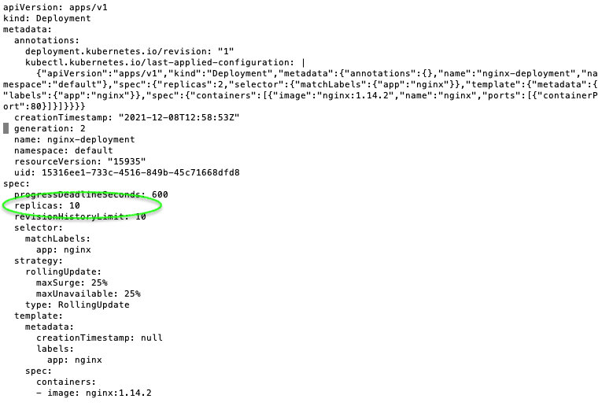

- Vérifiez de nouveau les PODs

```python
kubectl get pods
```

```python
# résultat
NAME                               READY   STATUS    RESTARTS   AGE
nginx-deployment-9456bbbf9-7rmw6   1/1     Running   0          7m24s
nginx-deployment-9456bbbf9-cqpxb   1/1     Running   0          7m24s
nginx-deployment-9456bbbf9-crhr9   1/1     Running   0          28m
nginx-deployment-9456bbbf9-hlxkn   1/1     Running   0          7m24s
nginx-deployment-9456bbbf9-j2k2p   1/1     Running   0          7m24s
nginx-deployment-9456bbbf9-q5669   1/1     Running   0          7m24s
nginx-deployment-9456bbbf9-qr7lp   1/1     Running   0          7m24s
nginx-deployment-9456bbbf9-r62z5   1/1     Running   0          7m24s
nginx-deployment-9456bbbf9-rpn8w   1/1     Running   0          28m
nginx-deployment-9456bbbf9-wzrwv   1/1     Running   0          7m24s
```

**- Étape 2 : Creation et exposition d'un service à partir d'un POD**

- Pour faire l'accès à l'application (port 80) à l'intérieur d'un POD, on va créer et exposer un service nommé "nginx-service"

```python
kubectl expose pod <pod_name> --type=NodePort --name=nginx-service --port=80
```

- Le service est exposé sur un port aléatoire (30941 dans ce cas). Pour afficher le numéro du port, tapez :

```python
kubectl get services
```

```python
## Résultat
NAME            TYPE        CLUSTER-IP    EXTERNAL-IP   PORT(S)        AGE
kubernetes      ClusterIP   10.96.0.1     <none>        443/TCP        3d21h
nginx-service   NodePort    10.101.2.82   <none>        80:30941/TCP   22s
```

- Ouvrez le navigateur et faites l'accés à l'application depuis l'un des noeuds (master ou workers)

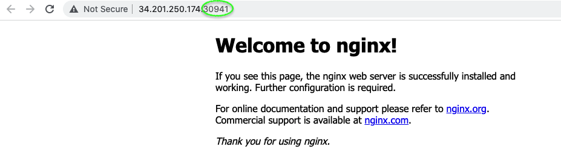

## Commandes de Réinitialisation

### Master node

- Pour faire la ré-initialisation, tapez les commandes suivantes :

```python
kubeadm reset && rm -rf /etc/cni/net.d
```

```python
kubeadm init
```

- Enfin, copiez la commande join

### Worker node

```python
kubeadm reset
```

- Enfin, collez la commande join